# Story 3

Kossi Akplaka

2024-03-03

In this story, I’ll use CDC API to retrieve firearm mortality data for each state per 100,000 persons. Then, after categorizing gun control laws per states, we’ll create a 5-point Likert scale categorizing gun control laws from most lax to strictest.

The goal of the story is to answer if stricter firearm control laws help reduce firearm mortality

## Import libraries

```r
library(tidyverse)
library(httr)
library(jsonlite)
library(ggplot2)
library(tidyr)
library(usmap)
library(gridExtra)
library(kableExtra)
```

## Load the data

Let’s access the firearm mortality data from the CDC using an available API (https://open.cdc.gov/apis.html)

```r
url <- "https://data.cdc.gov/resource/489q-934x.json"
response <- GET(url)
data <- content(response, as = "text")
df <- as.data.frame(fromJSON(data))

# View data
kable(head(df), "simple")
```

| year_and_quarter | time_period | cause_of_death | rate_type | unit | rate_overall | rate_sex_female | rate_sex_male | rate_alaska | rate_alabama | rate_arkansas | rate_arizona | rate_california | rate_colorado | rate_connecticut | rate_district_of_columbia | rate_delaware | rate_florida | rate_georgia | rate_hawaii | rate_iowa | rate_idaho | rate_illinois | rate_indiana | rate_kansas | rate_kentucky | rate_louisiana | rate_massachusetts | rate_maryland | rate_maine | … |
| --- | --- | --- | --- | --- | --- | --- | --- | --- | --- | --- | --- | --- | --- | --- | --- | --- | --- | --- | --- | --- | --- | --- | --- | --- | --- | --- | --- | --- | --- | --- |
| 2021 Q1 | 12 months ending with quarter | All causes | Age-adjusted | Deaths per 100,000 | 866.3 | 716.3 | 1040.4 | 779.2 | 1123.4 | 1043.1 | 853.2 | 767.7 | 760.9 | 784.3 | 904.8 | 866.2 | 757.3 | 957.4 | 585.9 | 848.3 | 789.6 | 861.5 | 981.8 | 901.2 | 1064.2 | 1080.3 | 768 | 847.9 | 785.3 | … |
| 2021 Q1 | 12 months ending with quarter | Alzheimer disease | Age-adjusted | Deaths per 100,000 | 32.1 | 36.8 | 24.8 | 28.2 | 51.2 | 44.1 | 31.3 | 41 | 36 | 20.6 | 11.1 | 35.4 | 19.7 | 45.9 | 22.4 | 29.7 | 37 | 28.3 | 32 | 24.2 | 31.7 | 45.3 | 17.8 | 16 | 27.6 | … |
| 2021 Q1 | 12 months ending with quarter | COVID-19 | Age-adjusted | Deaths per 100,000 | 120.7 | 94 | 153.9 | 44.4 | 160.2 | 130.6 | 142.1 | 128.5 | 83.6 | 138.9 | 148.6 | 106.8 | 80.6 | 130.5 | 20.7 | 119.9 | 79.2 | 121.3 | 132.8 | 121.8 | 109.6 | 146.7 | 126 | 111 | 36.1 | … |
| 2021 Q1 | 12 months ending with quarter | Cancer | Age-adjusted | Deaths per 100,000 | 142 | 122.8 | 167.7 | 143 | 160.5 | 160.7 | 125.5 | 128.5 | 123.4 | 132.1 | 136 | 149.1 | 134.4 | 145.8 | 124.1 | 145.4 | 135 | 148.2 | 160.6 | 148.1 | 177 | 158.1 | 132.8 | 139.5 | 157.5 | … |
| 2021 Q1 | 12 months ending with quarter | Chronic liver disease and cirrhosis | Age-adjusted | Deaths per 100,000 | 13.9 | 9.8 | 18.3 | 23.6 | 17.2 | 15.9 | 18.2 | 14.9 | 18.1 | 12.7 | 9 | 10.6 | 13.4 | 12.5 | 8.6 | 11.9 | 16 | 11.5 | 14.4 | 15.4 | 17.5 | 11.1 | 11.5 | 9.6 | 14.2 | … |
| 2021 Q1 | 12 months ending with quarter | Chronic lower respiratory diseases | Age-adjusted | Deaths per 100,000 | 33.8 | 30.9 | 37.5 | 28.4 | 50.4 | 57.5 | 34.5 | 26.3 | 36.6 | 22.5 | 18.9 | 32 | 31.2 | 39.5 | 16.9 | 35.9 | 36.8 | 31.3 | 49.5 | 40.9 | 52.7 | 38.9 | 25.2 | 25.3 | 36.8 | … |

## Data Tidying

Let’s filter the data to only include injury per firearm in 2023 Quarter 1, 12 months ending quarter, Age adjusted

```r
# Apply the filter to the data
firearm_data <- df %>%
    filter(cause_of_death == 'Firearm-related injury' &
         year_and_quarter == '2023 Q1' &
         time_period == '12 months ending with quarter' &
         rate_type == "Age-adjusted")

#Select only the states columns
firearm_df <- firearm_data[1, 9:59]

# Reformat the data
firearm_df <- firearm_df %>%
  gather(key = "state", value = "firearm_mortality_rate", starts_with("rate_")) %>%
  mutate(firearm_mortality_rate = as.numeric(firearm_mortality_rate),
         state = gsub("rate_", "", state)) %>%
  filter(state != "district_of_columbia") %>%
  arrange(state)

# View first 5 elements of the data
head(firearm_df)
```

```
##        state firearm_mortality_rate
## 1    alabama                   26.4
## 2     alaska                   21.4
## 3    arizona                   20.0
## 4   arkansas                   22.7
## 5 california                    8.6
## 6   colorado                   17.0
```

Now, let’s create a 5 point Likert scale categorizing gun control laws from loosest to strictest and assign each state to the most appropriate Likert bins

- Reference: “https://wisevoter.com/state-rankings/states-with-strictest-gun-laws/#”

```r
# Categories for  guns policies per states
likert_values <-c("Very loose", "Very loose","Very loose","Very loose","Very Strict",
                  "Strict","Very Strict","Strict","Moderate","Very loose",
                  "Very Strict","Very loose","Very Strict","Loose","Very loose",
                  "Very loose","Very loose","Very loose","Very loose","Very Strict",
                  "Very Strict","Moderate","Moderate","Very loose","Very loose","Very loose",
                  "Moderate","Moderate","Very loose","Very Strict","Moderate","Very Strict",
                  "Moderate","Very loose","Loose","Very loose","Strict","Strict",
                  "Strict","Very loose","Very loose","Very loose","Very loose",
                  "Very loose","Moderate","Strict","Strict","Very loose","Moderate","Very loose")

# Assuming your data frame is named df_ordered
firearm_df$gun_law <- likert_values

# Change the name of the column

firearm_df$state <- c("Alabama", "Alaska", "Arizona", "Arkansas", "California",
            "Colorado", "Connecticut", "Delaware", "Florida", "Georgia",
            "Hawaii", "Idaho", "Illinois", "Indiana", "Iowa", "Kansas",
            "Kentucky", "Louisiana", "Maine", "Maryland", "Massachusetts",
            "Michigan", "Minnesota", "Mississippi", "Missouri", "Montana",
            "Nebraska", "Nevada", "New Hampshire", "New Jersey", "New Mexico",
            "New York", "North Carolina", "North Dakota", "Ohio", "Oklahoma",
            "Oregon", "Pennsylvania", "Rhode Island", "South Carolina",
            "South Dakota", "Tennessee", "Texas", "Utah", "Vermont", "Virginia",
            "Washington", "West Virginia", "Wisconsin", "Wyoming")

# Print the data
head(firearm_df)
```

```
##        state firearm_mortality_rate     gun_law
## 1    Alabama                   26.4  Very loose
## 2     Alaska                   21.4  Very loose
## 3    Arizona                   20.0  Very loose
## 4   Arkansas                   22.7  Very loose
## 5 California                    8.6 Very Strict
## 6   Colorado                   17.0      Strict
```

## Data Visualization

### Correlation between firearm policy and mortality rate

Let’s calculate the correlation between strict firearm policy and the mortality rate.

```r
# Calculate correlation coefficient
correlation <- cor(firearm_df$firearm_mortality_rate, as.numeric(factor(firearm_df$gun_law, levels = c("Very loose", "Loose", "Moderate", "Strict", "Very Strict"))))

correlation
```

```
## [1] -0.6656803
```

The correlation coefficient of -0.6656803 indicates a strong negative correlation between firearm mortality rates and the strict gun control laws. This suggests that as gun control laws become stricter, firearm mortality rates tend to decrease.

### Create a heat map

Let’s visualize the relationship between gun control laws and firearm mortality rate

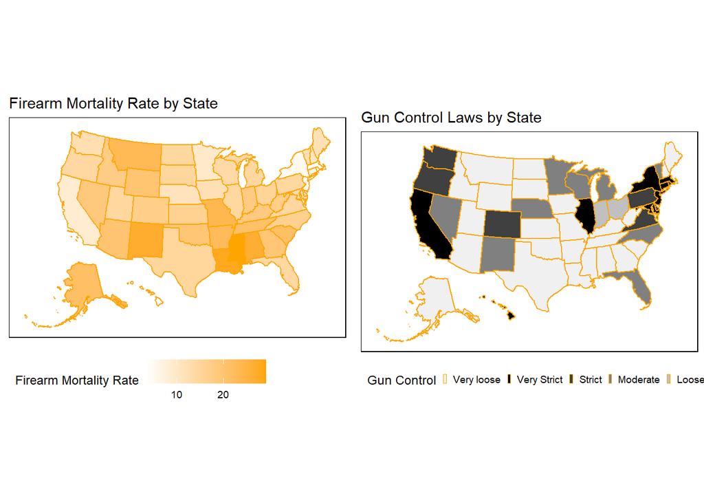

```r
# Plot US map for firearm mortality rates
plot_firearm <- plot_usmap(data = firearm_df, values = "firearm_mortality_rate", color = "orange", labels = FALSE) +
  scale_fill_continuous(low = "white", high = "orange", name = "Firearm Mortality Rate", label = scales::comma) +
  theme(legend.position = "bottom", panel.background = element_rect(colour = "black")) +
  labs(title = "Firearm Mortality Rate by State")

# Plot US map for gun control laws
plot_gun_law <- plot_usmap(data = firearm_df, values = "gun_law", color = "orange", labels = FALSE) +
  scale_fill_manual(values = c("#F0F0F0", "#000000", "#404040", "#808080","#C0C0C0"),
                    name = "Gun Control",
                    breaks = unique(firearm_df$gun_law)) +
  theme(legend.position = "bottom",
        panel.background = element_rect(colour = "black"),
        legend.key.size = unit(0.1, "cm")) +
  labs(title = "Gun Control Laws by State")

# Arrange plots side by side
grid.arrange(plot_firearm, plot_gun_law, ncol = 2)
```

The heat map shows that the states with the most strictest guns laws have a lower mortality rates.

## Conclusion

In this story, we aim to explore the impact of stricter firearm control laws on reduce firearm mortality rates. Through correlating strict firearm control laws across states with their respective firearm mortality rates and visualizing the data via a heat map, we observe a notable trend: As gun control laws tighten, firearm mortality rates generally decreases.

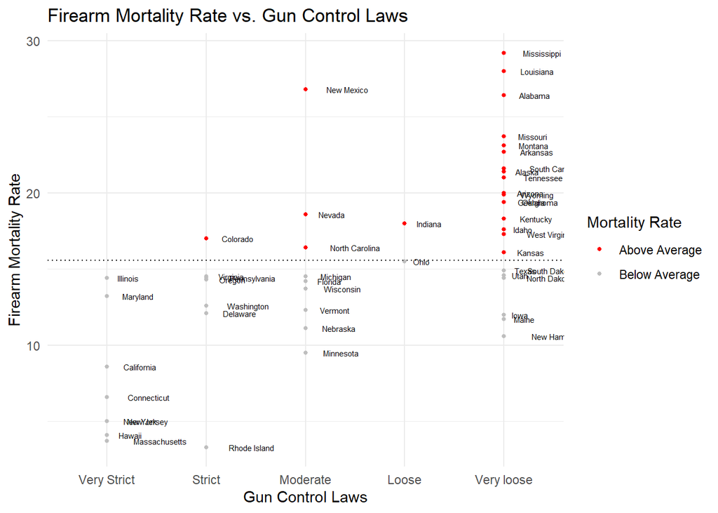

```r
# Calculate the average firearm mortality rate
average_rate <- mean(firearm_df$firearm_mortality_rate)


# Reorder the factor levels of gun_law
firearm_df$gun_law <- factor(firearm_df$gun_law, levels = c("Very Strict", "Strict", "Moderate", "Loose", "Very loose"))

# Create the scatter plot
ggplot(firearm_df, aes(x = gun_law, y = firearm_mortality_rate, label = state)) +
  geom_point(aes(color = ifelse(firearm_mortality_rate > average_rate,  "Above Average", "Below Average")), size = 1) +
  geom_text(size = 2, hjust = -0.5) +
  scale_color_manual(values = c( "red", "grey")) +
  labs(x = "Gun Control Laws", y = "Firearm Mortality Rate", title = "Firearm Mortality Rate vs. Gun Control Laws") +
  geom_hline(yintercept = average_rate, linetype = "dotted") +
  theme_minimal() +
  guides(color = guide_legend(title = "Mortality Rate",
                              ))
```

The national average for firearm mortality stands at 15.5 per 100,000 persons.

Although it’s important to consider other factors that could contribute to lower mortality rates in these states, the data suggests that stricter gun control laws correspond to lower firearm mortality rates.